# Lab 1: Intro to R Week 4

### Exercise 3: Make a normal probability plot of sim_norm. Do all of the points fall on the line? How does this plot compare to the probability plot for the real data? (Since sim_norm is not a dataframe, it can be put directly into the sample argument and the data argument can be dropped.)

For the Dairy Queen dataset, the sim_norm plot appears to have almost, or all points fall on the line. This is expected, as this plot takes the Dairy Queen data and uses the rnorm() function to simulate a normal distribution. When comparing this plot to the real data, some variability can be seen near the tail end of the distribution. There are some definite irregularities in the real data, as evidenced by the steep climb in the line shown on real data plot at the end. This supports our previous finding, and would indicate to me a slightly right skewed dataset.

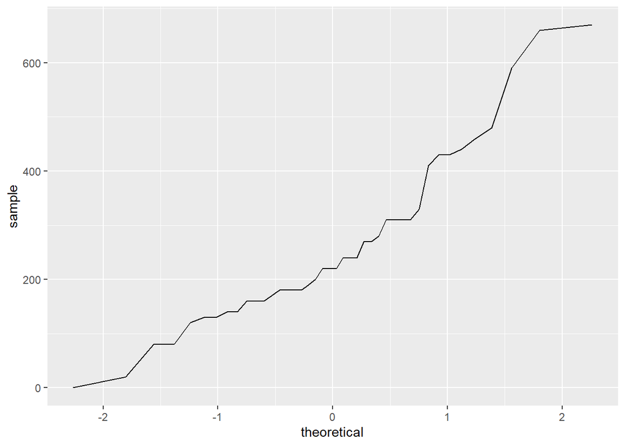

```r
ggplot(data = dairy_queen, aes(sample = cal_fat)) +
  geom_line(stat = "qq")
```

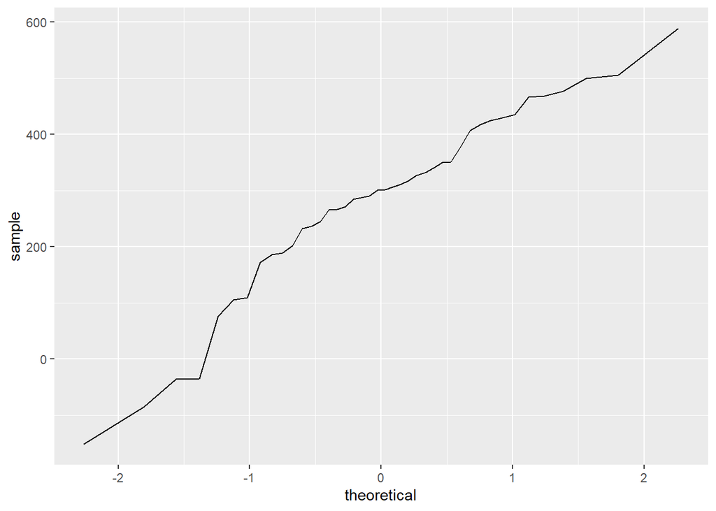

```r
sim_norm <- rnorm(n = nrow(dairy_queen), mean = dqmean, sd = dqsd)

ggplot() +
  geom_line(stat = "qq", aes(sample=sim_norm)) #normal probability plot of
```

```r
#sim_norm
```

### Exercise 4: Does the normal probability plot for the calories from fat look similar to the plots created for the simulated data? That is, do the plots provide evidence that the calories from fat are nearly normal?

The normal probability plot for dairy queen calories from fat appears to be mostly similar to the simulated data, with the most difference showing in the upper tail end of the graphs. Where the actual data is similar to all simulated plots in the beginning and middle sections of the data, it only resembles the pattern of maybe one or two of the simulated datasets at the right tail end.

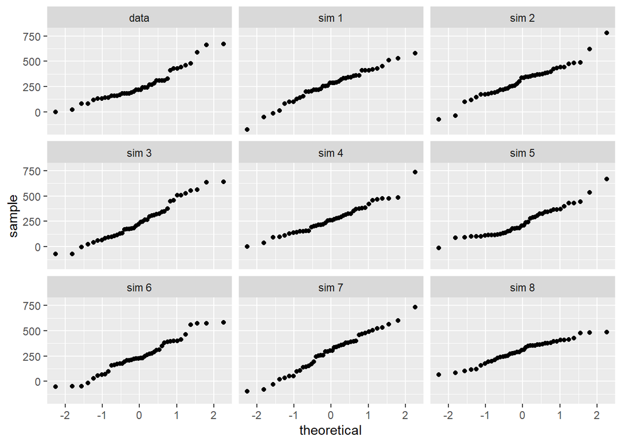

```r
qqnormsim(sample = cal_fat, data = dairy_queen)
```

### Exercise 5: Using the same technique, determine whether or not the calories from McDonald’s menu appear to come from a normal distribution.

Based on the same technique for McDonalds, the calories from fat for the menu do not appear to be normally distributed. When comparing the normal probability plot for the real data set to the simulated normal dataset, some obvious differences are visually present. First, the trajectory of the both lines at the beginning and middle of the plot vary. In the real dataset, the line is much more shallow (i.e. stays much closer to the x axis), as opposed to the simulated normal dataset. When comparing normal probability plots from the real dataset to the simulated datasets using qqnormsim(), the behavior above is further validated. At the tail of the datasets, there is a large difference in visual appearance. The real dataset rises significantly steeply on the y-axis, whereas the simulated datasets appear to be much more linear in comparison to the rest of the data.

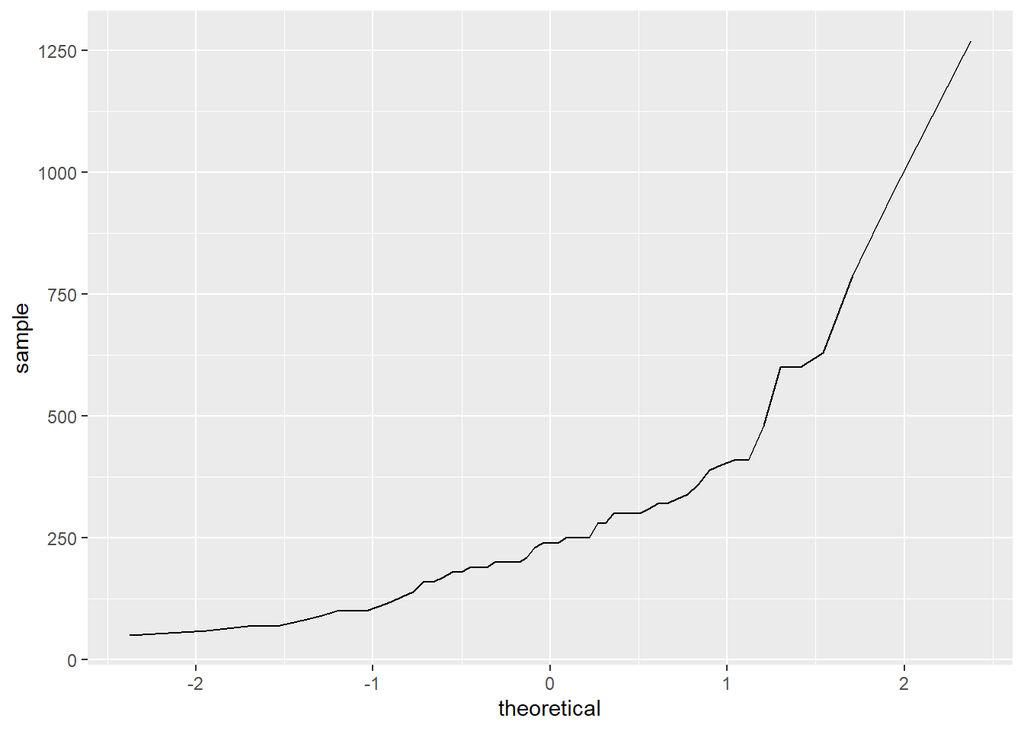

```r
ggplot(data = mcdonalds, aes(sample = cal_fat)) +
  geom_line(stat = "qq") ##QQPlot for real data set
```

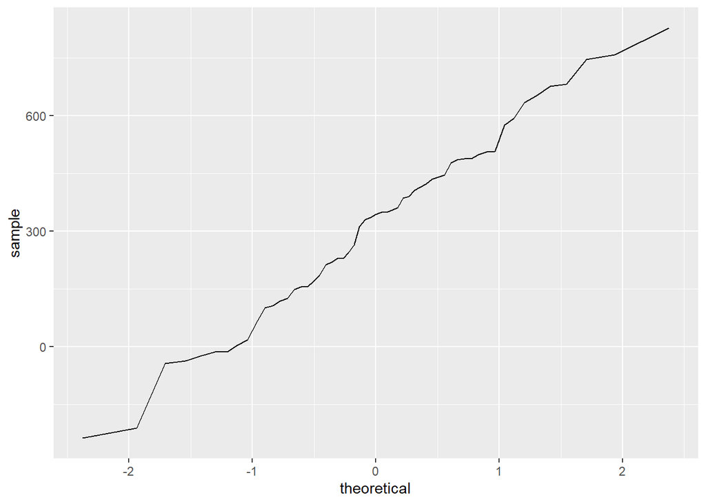

```r
sim_normmd <- rnorm(n = nrow(mcdonalds), mean = mdmean, sd = mdsd)

ggplot() +
  geom_line(stat = "qq", aes(sample=sim_normmd)) #normal probability plot of
```

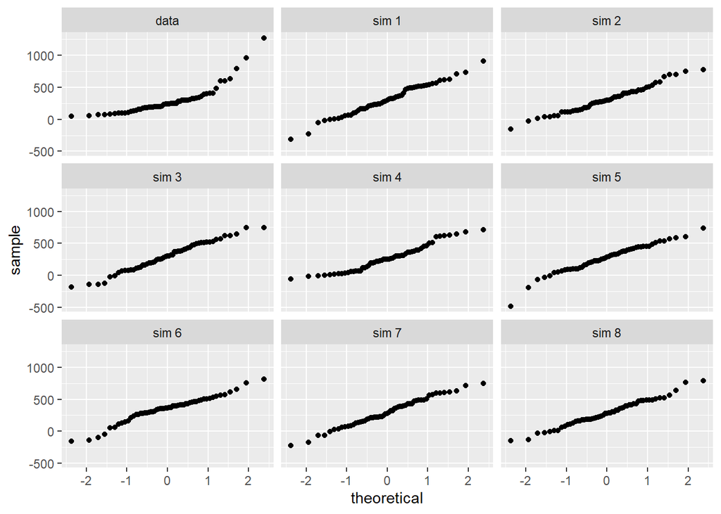

```r
#sim_norm

qqnormsim(sample = cal_fat, data = mcdonalds)
```

### Exercise 6: Write out two probability questions that you would like to answer about any of the restaurants in this dataset. Calculate those probabilities using both the theoretical normal distribution as well as the empirical distribution (four probabilities in all). Which one had a closer agreement between the two methods?

What is the probability that a randomly chosen Sonic product has more than 1200 mg of sodium? Answer: The theoretical probability of a randomly chosen Sonic product containing more than 1200 mg of sodium is 58%, and 51% using the empirical probability.

What is the probability that a randomly chosen Burger King product has less than 10 g of sugar? Answer: The theoretical probability of a randomly chosen Burger King product containing less than 10 g of sodium is 62%%, and 70% using the empirical probability.

Sonic has a very slightly closer agreement between the two methods.

```r
Sonic <- fastfood %>%
  filter(restaurant == "Sonic")
BK <- fastfood %>%
  filter(restaurant == "Burger King")

#Sonic Calculations
sonicmean <- mean(Sonic$sodium)
sonicsd <- sd(Sonic$sodium)
1 - pnorm(1200, mean = sonicmean, sd = sonicsd) #Theoretical Probability
```

```
## [1] 0.5896533
```

```r
Sonic %>%
  filter(sodium > 1200) %>%
  summarise(percent = n() / nrow(Sonic)) #Empirical Probability
```

```
## # A tibble: 1 × 1
##   percent
##     <dbl>
## 1   0.509
```

```r
#BK Calculations
BKmean <- mean(BK$sugar)
BKsd <- sd(BK$sugar)
pnorm(10, mean = BKmean, sd = BKsd) #Theoretical Probability
```

```
## [1] 0.6153453
```

```r
BK %>%
  filter(sugar < 10) %>%
  summarise(percent = n() / nrow(BK)) #Empirical Probability
```

```
## # A tibble: 1 × 1
##   percent
##     <dbl>
## 1     0.7
```

### Exercise 7: Now let’s consider some of the other variables in the dataset. Out of all the different restaurants, which ones’ distribution is the closest to normal for sodium?

After calculating the theoretical and empirical probabbilities for sodium for all restaraunts, Arbys and Taco Bell are both within 3%. Therefore, there is a tie between those two restaraunts for closest to normal for sodium.

```r
CF <- fastfood %>%
  filter(restaurant == "Chick Fil-A")

AB <- fastfood %>%
  filter(restaurant == "Arbys")

Sub <- fastfood %>%
  filter(restaurant == "Subway")

TBell <- fastfood %>%
  filter(restaurant == "Taco Bell")

BKs <- fastfood %>%
  filter(restaurant == "Burger King")

CFmean <- mean(CF$sodium)
CFsd <- sd(CF$sodium)
1 - pnorm(1200, mean = CFmean, sd = CFsd) #Theoretical Probability
```

```
## [1] 0.4733922
```

```r
CF %>%
  filter(sodium > 1200) %>%
  summarise(percent = n() / nrow(CF)) #Empirical Probability
```

```
## # A tibble: 1 × 1
##   percent
##     <dbl>
## 1   0.370
```

```r
#CF th= 47%, EM=37%, AB th=68%, EM=65%, Sub th=54%, EM=47%, Tbell th=35%, EM=32%,
#BKs th=52%, EM=46%, Sonic th=58%, EM=51%

ABmean <- mean(AB$sodium)
ABsd <- sd(AB$sodium)
1 - pnorm(1200, mean = ABmean, sd = ABsd) #Theoretical Probability
```

```
## [1] 0.6826236
```

```r
AB %>%
  filter(sodium > 1200) %>%
  summarise(percent = n() / nrow(AB)) #Empirical Probability
```

```
## # A tibble: 1 × 1
##   percent
##     <dbl>
## 1   0.655
```

```r
Submean <- mean(Sub$sodium)
Subsd <- sd(Sub$sodium)
1 - pnorm(1200, mean = Submean, sd = Subsd) #Theoretical Probability
```

```
## [1] 0.5390833
```

```r
Sub %>%
  filter(sodium > 1200) %>%
  summarise(percent = n() / nrow(Sub)) #Empirical Probability
```

```
## # A tibble: 1 × 1
##   percent
##     <dbl>
## 1   0.469
```

```r
TBellmean <- mean(TBell$sodium)
TBellsd <- sd(TBell$sodium)
1 - pnorm(1200, mean = TBellmean, sd = TBellsd) #Theoretical Probability
```

```
## [1] 0.3473283
```

```r
TBell %>%
  filter(sodium > 1200) %>%
  summarise(percent = n() / nrow(TBell)) #Empirical Probability
```

```
## # A tibble: 1 × 1
##   percent
##     <dbl>
## 1   0.322
```

```r
BKsmean <- mean(BKs$sodium)
BKssd <- sd(BKs$sodium)
1 - pnorm(1200, mean = BKsmean, sd = BKssd) #Theoretical Probability
```

```
## [1] 0.5188047
```

```r
BKs %>%
  filter(sodium > 1200) %>%
  summarise(percent = n() / nrow(BKs)) #Empirical Probability
```

```
## # A tibble: 1 × 1
##   percent
##     <dbl>
## 1   0.457
```

## Excercise 8: Note that some of the normal probability plots for sodium distributions seem to have a stepwise pattern. why do you think this might be the case?

Stepwise patterns tend to occur more in discrete data. Given that sodium is discrete, and is distinctly counted in what I’m assuming to be milligrams, this makes sense within the normal probability plots.

## Exercise 9: As you can see, normal probability plots can be used both to assess normality and visualize skewness. Make a normal probability plot for the total carbohydrates from a restaurant of your choice. Based on this normal probability plot, is this variable left skewed, symmetric, or right skewed? Use a histogram to confirm your findings.

Based on the first two normal probability plots, I would expect the data to be fairly symmetric, with maybe a slight right skew. As confirmed within the histogram, the data is slightly skewed right.

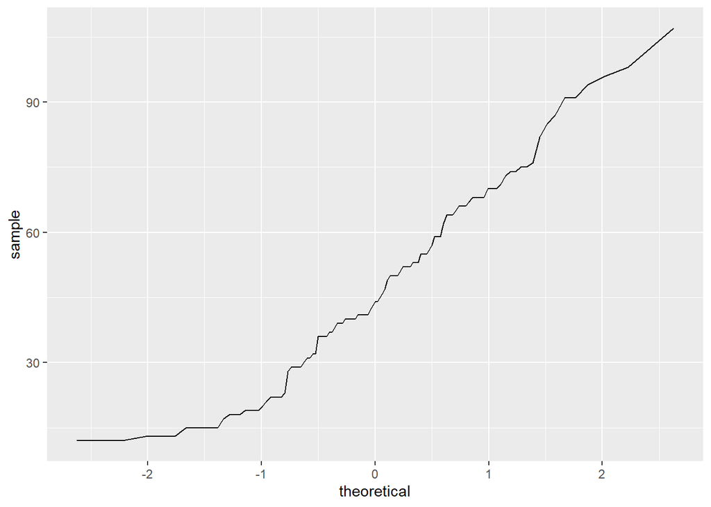

```r
ggplot(data = TBell, aes(sample = total_carb)) +
  geom_line(stat = "qq") ##QQ Plot of the real data to compare with simulated
```

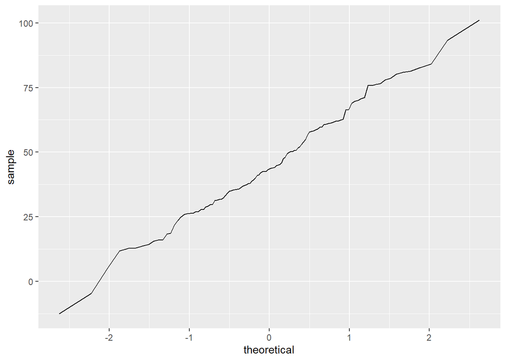

```r
#normal data below

TBellmeanc <- mean(TBell$total_carb)
TBellsdc <- sd(TBell$total_carb)

sim_normtb <- rnorm(n = nrow(TBell), mean = TBellmeanc, sd = TBellsdc)

ggplot() +
  geom_line(stat = "qq", aes(sample=sim_normtb)) #normal probability plot of
```

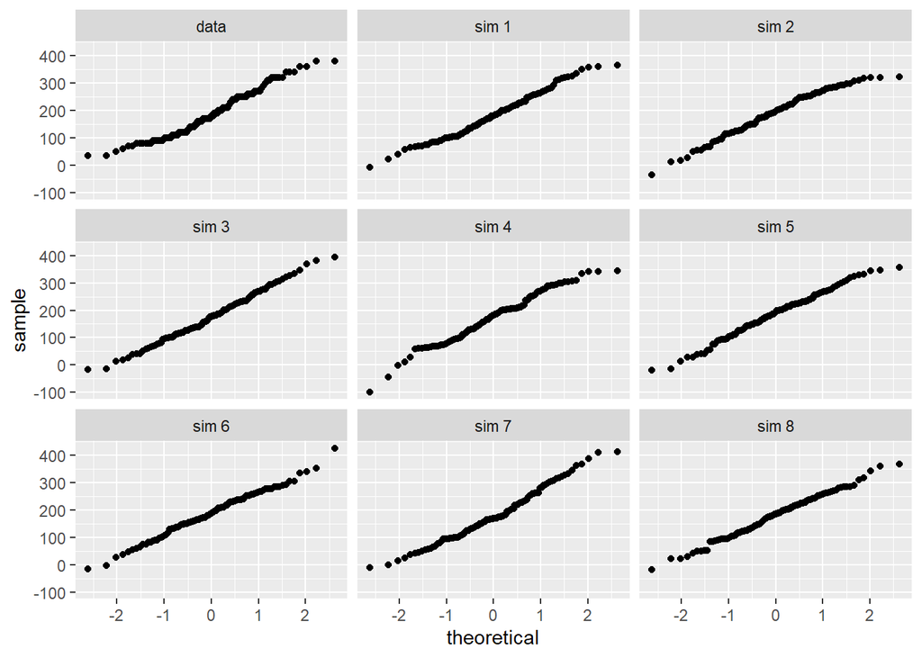

```r
#sim_norm for Taco Bell total carbs

qqnormsim(sample = cal_fat, data = TBell) #Comparison of real Taco Bell data to
```

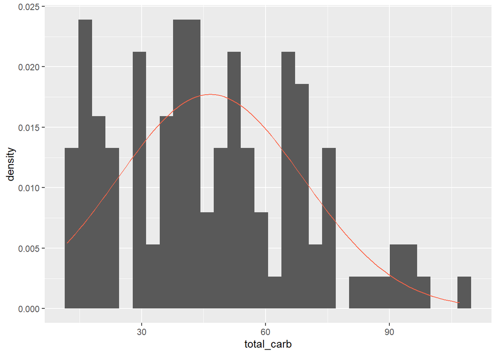

```r
#simulated data

ggplot(data = TBell, aes(x = total_carb)) +
  geom_blank() +
  geom_histogram(aes(y = ..density..)) +
  stat_function(fun = dnorm, args = c(mean = TBellmeanc, sd = TBellsdc), col = "tomato")
```